# DACSS 697D Post 4

text as data

homework

Assignment 4 for DACSS 697D Course ‘Text as Data’: “Preprocessing”

Kristina Becvar https://www.kristinabecvar.com  
03-31-2022

# Getting Started

I am beginning to pull in the text collection that I will be analyzing for my final project in the course. I started pulling articles by month beginning January 2020 through December 2021. For my initial text collection, I am collecting articles using the New York Times API for the search query “Afghanistan”. I am not limiting my search by any filter at this time. However, I am limited in that the article search API for the New York Times does not pull the entire article; rather, I have been able to pull the abstract/summary, lead paragraph, and snippet for each article as well as the keywords, authors, sections, and url. In addition, I can get the article titles for both the print and online versions of the article.

To pull the data, I had to reduce the queries into more workable groups that would not time out, given the NYT API limits. I was able to pull the 3,442 articles by year (2020, then 2021 in two parts), then assemble them into a dataframe. I will not run the code in this post, as it was already run and is an exhaustive process.

```r
# For articles from 2020

#url2020 <- ('https://api.nytimes.com/svc/search/v2/articlesearch.json?begin_date=20200101&end_date=20201231&q=afghanistan&api-key=GTp3efxVZiGO75Iox9uZJ8ZTjIMjDWsM')

#query2020 <- fromJSON(url2020)

#max.pages2020 <- ceiling((query2020$response$meta$hits[1] / 10)-1)

#pages2020 <- list()
#for(i in 0:max.pages2020){
  #search2020 <- fromJSON(paste0(url2020, "&page=", i), flatten = TRUE) %>% data.frame()
  #message("Retrieving page ", i)
  #pages2020[[i+1]] <- search2020
  #Sys.sleep(10)
  #}

#pages2020[[i+1]] <- search2020
#afghanistan.articles.2020 <- rbind_pages(pages2020)

#save(afghanistan.articles.2020,file="afghanistan_articles_2020.Rdata")

# For January to August 2021

#url2021a <- ('https://api.nytimes.com/svc/search/v2/articlesearch.json?begin_date=20210101&end_date=20210831&q=afghanistan&api-key=GTp3efxVZiGO75Iox9uZJ8ZTjIMjDWsM')

#query2021a <- fromJSON(url2021a)

#max.pages2021a <- ceiling((query2021a$response$meta$hits[1] / 10)-1)

#pages2021a <- list()
#for(i in 0:max.pages2021a){
  #search2021a <- fromJSON(paste0(url2021a, "&page=", i), flatten = TRUE) %>% data.frame()
  #message("Retrieving page ", i)
  #pages2021a[[i+1]] <- search2021a
  #Sys.sleep(10)
#}

#pages2021a[[i+1]] <- search2021a
#afghanistan.articles.2021a <- rbind_pages(pages2021a)

#save(afghanistan.articles.2021a,file="afghanistan_articles_2021a.Rdata")

# For September-December 2021

url2021b <- ('https://api.nytimes.com/svc/search/v2/articlesearch.json?begin_date=20210901&end_date=20211231&q=afghanistan&api-key=GTp3efxVZiGO75Iox9uZJ8ZTjIMjDWsM')

#query2021b <- fromJSON(url2021b)

#max.pages2021b <- ceiling((query2021b$response$meta$hits[1] / 10)-1)

#pages2021b <- list()
#for(i in 0:max.pages2021b){
  #search2021b <- fromJSON(paste0(url2021b, "&page=", i), flatten = TRUE) %>% data.frame()
  #message("Retrieving page ", i)
  #pages2021b[[i+1]] <- search2021b
  #Sys.sleep(10)
#}

#pages2021b[[i+1]] <- search2021b
#afghanistan.articles.2021b <- rbind_pages(pages2021b)

#save(afghanistan.articles.2021b,file="afghanistan_articles_2021b.Rdata")


# Create shell for data

#afghanistan.articles.all <- c()

#afghanistan.articles.all <- rbind_pages(c(pages2020, pages2021a, pages2021b))
```

After compiling the data, I re-formatted the date column and saving the formatted tibble for offline access.

```r
#afghanistan.articles.table<- as_tibble(cbind(
  #date=afghanistan.articles.all$response.docs.pub_date,
  #abstract=afghanistan.articles.all$response.docs.abstract,
  #lead.paragraph=afghanistan.articles.all$response.docs.lead_paragraph,
  #snippet=afghanistan.articles.all$response.docs.snippet,
  #section.name=afghanistan.articles.all$response.docs.section_name,
  #subsection.name=afghanistan.articles.all$response.docs.subsection_name,
  #news.desk=afghanistan.articles.all$response.docs.news_desk,
  #byline=afghanistan.articles.all$response.docs.byline.original,
  #headline.main=afghanistan.articles.all$response.docs.headline.main,
  #headline.print=afghanistan.articles.all$response.docs.headline.print_headline,
  #headline.kicker=afghanistan.articles.all$response.docs.headline.kicker,
  #material=afghanistan.articles.all$response.docs.type_of_material,
  #url=afghanistan.articles.all$response.docs.web_url
  #))

#afghanistan.articles.table$date <- substr(afghanistan.articles.table$date, 1, nchar(afghanistan.articles.table$date)-14)

#afghanistan.articles.table$date <- as.Date(afghanistan.articles.table$date, "%Y-%m-%d")

#save(afghanistan.articles.table,file="afghanistan.articles.table.Rdata")

#write.table(afghanistan.articles.table, file = "~/GitHub/DACSS.697D/Text as Data Spring22/afghanistan.articles.table.csv", sep=",", row.names=FALSE)
```

Initial data collection complete!

Now to the active review of the data. Loading the data from my collection phase:

```r
load("afghanistan.articles.table.RData")

afghanistan_lead <- read.csv("lead.paragraph.table.csv")

afghanistan_articles <- as.data.frame(afghanistan_lead)
```

Creating a corpus of the lead paragraphs of each article

```r
afghanistan_corpus <- corpus(afghanistan_articles)
afghanistan_summary <- summary(afghanistan_corpus)
afghanistan_summary
```

```
Corpus consisting of 3442 documents, showing 100 documents:

    Text Types Tokens Sentences doc.id      date         section.name
   text1    32     40         1      1  1/1/2020        Today’s Paper
   text2    23     26         1      2  1/2/2020                 Arts
   text3   109    170         9      3  1/2/2020             Magazine
   text4    49     56         1      4  1/3/2020         Business Day
   text5    23     25         3      5  1/3/2020             Magazine
   text6    46     60         3      6  1/3/2020           Obituaries
   text7    43     55         3      7  1/3/2020              Opinion
   text8    48     64         2      8  1/3/2020              Opinion
   text9    41     51         1      9  1/3/2020                 U.S.
  text10    31     35         1     10  1/3/2020                 U.S.
  text11    38     45         2     11  1/3/2020                World
  text12    11     11         1     12  1/4/2020              Opinion
  text13    36     45         4     13  1/4/2020              Opinion
  text14    57     68         3     14  1/4/2020                 U.S.
  text15    27     29         1     15  1/4/2020                 U.S.
  text16    54     61         2     16  1/4/2020                 U.S.
  text17    33     37         1     17  1/4/2020                World
  text18    47     51         1     18  1/4/2020                World
  text19    21     24         1     19  1/4/2020                World
  text20    32     42         3     20  1/5/2020              Opinion
  text21    41     56         2     21  1/5/2020                 U.S.
  text22    26     28         1     22  1/5/2020                World
  text23    14     14         2     23  1/6/2020             Briefing
  text24    14     14         2     24  1/6/2020             Briefing
  text25    10     11         1     25  1/6/2020             Magazine
  text26    62     76         3     26  1/6/2020              Opinion
  text27     4      4         1     27  1/6/2020              Opinion
  text28    24     24         1     28  1/6/2020                 U.S.
  text29    35     45         2     29  1/6/2020                 U.S.
  text30    33     34         1     30  1/6/2020                World
  text31    56     67         2     31  1/6/2020                World
  text32    42     55         1     32  1/7/2020                 Arts
  text33    42     54         1     33  1/7/2020         Business Day
  text34    46     61         2     34  1/7/2020             New York
  text35    69     91         4     35  1/7/2020              Opinion
  text36    63     78         2     36  1/7/2020              Opinion
  text37    59     79         4     37  1/7/2020                 U.S.
```

[output cut: 553 more lines]

```
                News
                News
               Op-Ed
               Op-Ed
 Interactive Feature
 Interactive Feature
                News
                News
                News
                News
                News
                News
                News
 Interactive Feature
 Interactive Feature
```

```r
head(afghanistan_summary)
```

```
   Text Types Tokens Sentences doc.id     date  section.name
1 text1    32     40         1      1 1/1/2020 Today’s Paper
2 text2    23     26         1      2 1/2/2020          Arts
3 text3   109    170         9      3 1/2/2020      Magazine
4 text4    49     56         1      4 1/3/2020  Business Day
5 text5    23     25         3      5 1/3/2020      Magazine
6 text6    46     60         3      6 1/3/2020    Obituaries
  news.desk                                       byline
1   Summary                                         <NA>
2   Weekend                                 By Mike Hale
3  Magazine               By Fahim Abed and Fatima Faizi
4  Business        By Ben Dooley and David Yaffe-Bellany
5  Magazine                             By C. J. Chivers
6   Foreign By Tim Arango, Ronen Bergman and Ben Hubbard
                                                                         headline.main
```

[output cut: 20 more lines]

Next, we move to tokenization.

```
Tokens consisting of 3,442 documents and 11 docvars.
text1 :
 [1] "\""      "He's"    "a"       "Rambo"   "version" "of"
 [7] "the"     "same"    "story"   "Trump"   "has"     "been"
[ ... and 28 more ]

text2 :
 [1] "Sign"            "up"              "for"
 [4] "our"             "Watching"        "newsletter"
 [7] "to"              "get"             "recommendations"
[10] "on"              "the"             "best"
[ ... and 14 more ]

text3 :
 [1] "At"             "least"          "87"
 [4] "pro-government" "forces"         "and"
 [7] "12"             "civilians"      "were"
[10] "killed"         "in"             "Afghanistan"
[ ... and 158 more ]

text4 :
 [1] "TOKYO"  "-"      "Carlos" "Ghosn"  "was"    "aided"  "in"
 [8] "his"    "escape" "from"   "Japan"  "by"
[ ... and 44 more ]

text5 :
 [1] "You're"     "reading"    "this"       "week's"     "At"
 [6] "War"        "newsletter" "."          "Sign"       "up"
[11] "here"       "to"
[ ... and 13 more ]

text6 :
 [1] "He"        "changed"   "the"       "shape"     "of"
 [6] "the"       "Syrian"    "civil"     "war"       "and"
[11] "tightened" "Iran's"
[ ... and 48 more ]

[ reached max_ndoc ... 3,436 more documents ]
```

And remove punctuation

```r
afghanistan_tokens <- tokens(afghanistan_corpus,
    remove_punct = T)
print(afghanistan_tokens)
```

```
Tokens consisting of 3,442 documents and 11 docvars.
text1 :
 [1] "He's"    "a"       "Rambo"   "version" "of"      "the"
 [7] "same"    "story"   "Trump"   "has"     "been"    "telling"
[ ... and 22 more ]

text2 :
 [1] "Sign"            "up"              "for"
 [4] "our"             "Watching"        "newsletter"
 [7] "to"              "get"             "recommendations"
[10] "on"              "the"             "best"
[ ... and 12 more ]

text3 :
 [1] "At"             "least"          "87"
 [4] "pro-government" "forces"         "and"
 [7] "12"             "civilians"      "were"
[10] "killed"         "in"             "Afghanistan"
[ ... and 136 more ]

text4 :
 [1] "TOKYO"  "Carlos" "Ghosn"  "was"    "aided"  "in"     "his"
 [8] "escape" "from"   "Japan"  "by"     "an"
[ ... and 40 more ]

text5 :
 [1] "You're"     "reading"    "this"       "week's"     "At"
 [6] "War"        "newsletter" "Sign"       "up"         "here"
[11] "to"         "get"
[ ... and 11 more ]

text6 :
 [1] "He"        "changed"   "the"       "shape"     "of"
 [6] "the"       "Syrian"    "civil"     "war"       "and"
[11] "tightened" "Iran's"
[ ... and 42 more ]

[ reached max_ndoc ... 3,436 more documents ]
```

With quanteda, we can remove stopwords using any of few pre-defined lists that come shipped with the package. Here, we can print that list out first, then remove the tokens:

```
  [1] "i"          "me"         "my"         "myself"     "we"
  [6] "our"        "ours"       "ourselves"  "you"        "your"
 [11] "yours"      "yourself"   "yourselves" "he"         "him"
 [16] "his"        "himself"    "she"        "her"        "hers"
 [21] "herself"    "it"         "its"        "itself"     "they"
 [26] "them"       "their"      "theirs"     "themselves" "what"
 [31] "which"      "who"        "whom"       "this"       "that"
 [36] "these"      "those"      "am"         "is"         "are"
 [41] "was"        "were"       "be"         "been"       "being"
 [46] "have"       "has"        "had"        "having"     "do"
 [51] "does"       "did"        "doing"      "would"      "should"
 [56] "could"      "ought"      "i'm"        "you're"     "he's"
 [61] "she's"      "it's"       "we're"      "they're"    "i've"
 [66] "you've"     "we've"      "they've"    "i'd"        "you'd"
 [71] "he'd"       "she'd"      "we'd"       "they'd"     "i'll"
```

[output cut: 20 more lines]

Next, I’ll remove those stopwords.

```r
# remove stopwords from our tokens object
afghanistan_tokens <- tokens_select(afghanistan_tokens,
                                           pattern = stopwords("en"),
                                           selection = "remove")

print(afghanistan_tokens)
```

```
Tokens consisting of 3,442 documents and 11 docvars.
text1 :
 [1] "Rambo"   "version" "story"   "Trump"   "telling" "deep"
 [7] "state"   "trying"  "screw"   "media"   "bad"     "rich"
[ ... and 2 more ]

text2 :
 [1] "Sign"            "Watching"        "newsletter"
 [4] "get"             "recommendations" "best"
 [7] "films"           "TV"              "shows"
[10] "stream"          "watch"           "delivered"
[ ... and 1 more ]

text3 :
 [1] "least"          "87"             "pro-government"
 [4] "forces"         "12"             "civilians"
 [7] "killed"         "Afghanistan"    "past"
[10] "week"           "violent"        "incidents"
[ ... and 88 more ]

text4 :
 [1] "TOKYO"       "Carlos"      "Ghosn"       "aided"
 [5] "escape"      "Japan"       "American"    "security"
 [9] "consultant"  "accompanied" "flight"      "country"
[ ... and 15 more ]

text5 :
 [1] "reading"    "week's"     "War"        "newsletter" "Sign"
 [6] "get"        "delivered"  "inbox"      "every"      "Friday"
[11] "Email"      "us"
[ ... and 1 more ]

text6 :
 [1] "changed"   "shape"     "Syrian"    "civil"     "war"
 [6] "tightened" "Iran's"    "grip"      "Iraq"      "behind"
[11] "hundreds"  "American"
[ ... and 20 more ]

[ reached max_ndoc ... 3,436 more documents ]
```

## Dictionary Analysis

The basic idea with a dictionary analysis is to identify a set of words that connect to a central concept, and to count the frequency of that set of words within a document. The set of words is the dictionary; as you might quickly realize, a more appropriate name is probably thesaurus.

### liwcalike()

There are a couple of ways to do this. First, the quanteda.dictionaries package contains the liwcalike() function, which takes a corpus or character vector and carries out an analysis — based on a provided dictionary — that mimics the pay-to-play software LIWC (Linguistic Inquiry and Word Count see [here](https://www.liwc.app/)). The LIWC software calculates the percentage of the document that reflects a host of different characteristics. We are going to focus on positive and negative language, but keep in mind that there are lots of other dimensions that could be of interest.

```
 [1] "docname"      "Segment"      "WPS"          "WC"
 [5] "Sixltr"       "Dic"          "anger"        "anticipation"
 [9] "disgust"      "fear"         "joy"          "negative"
[13] "positive"     "sadness"      "surprise"     "trust"
[17] "AllPunc"      "Period"       "Comma"        "Colon"
[21] "SemiC"        "QMark"        "Exclam"       "Dash"
[25] "Quote"        "Apostro"      "Parenth"      "OtherP"
```

Polarity: The most positive selections

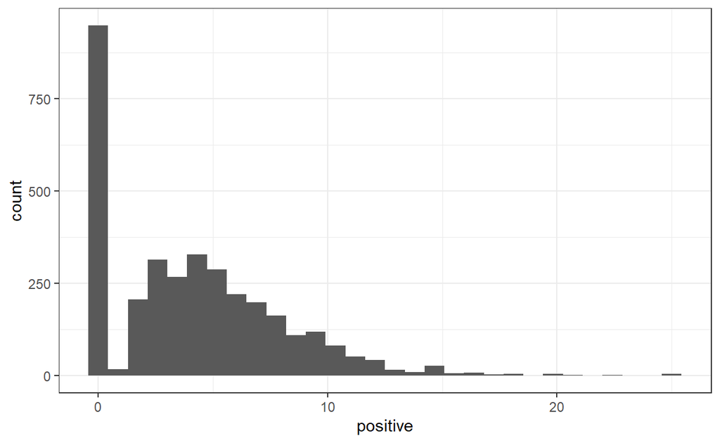

and negative

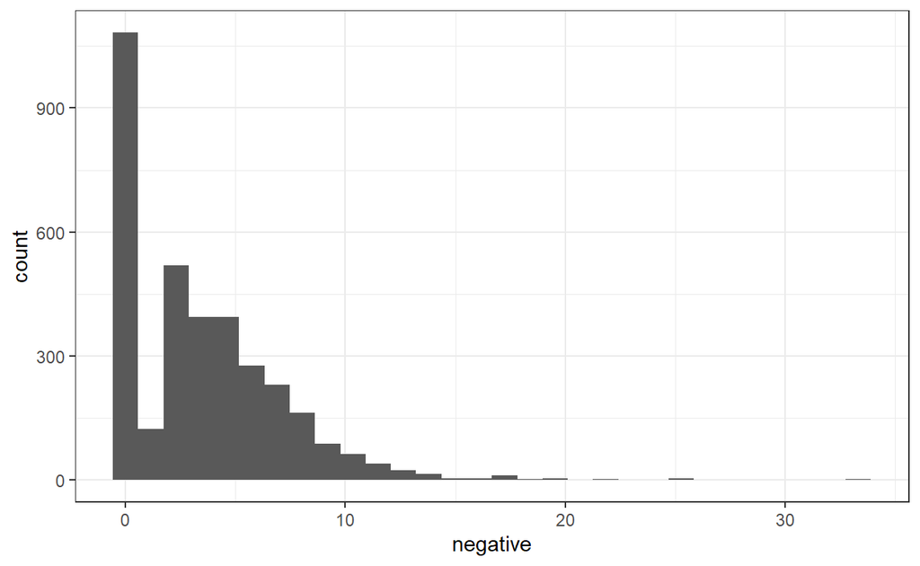

Based on that, let’s look at those that are out in the right tail (i.e., which are greater than 15).

```
Corpus consisting of 36 documents and 11 docvars.
text109 :
"Can a woman be president of the United States?"

text277 :
"KABUL, Afghanistan — Momentum is building toward peace in Af..."

text580 :
"On a holiday that usually mixes somber remembrance and bliss..."

text608 :
"WASHINGTON — Gen. Mark A. Milley was never meant to be Presi..."

text674 :
"For anyone trying to make sense of the Supreme Court run by ..."

text725 :
"WASHINGTON — A female National Guard soldier graduated from ..."

[ reached max_ndoc ... 30 more documents ]
```

and negative

```
Corpus consisting of 28 documents and 11 docvars.
text280 :
"— Parisa, an inmate at Herat Women’s Prison"

text290 :
"This war is different."

text310 :
"[Read the Afghan War Casualty Report from previous months.]"

text455 :
"What happens when the pandemic comes to a country in conflic..."

text479 :
"Donations flooded in to fight the virus devastating the city..."

text504 :
"[Read the Afghan War Casualty Report from previous weeks.]"

[ reached max_ndoc ... 22 more documents ]
```

Looking at the tutorial approach to considering addressing the polarity:

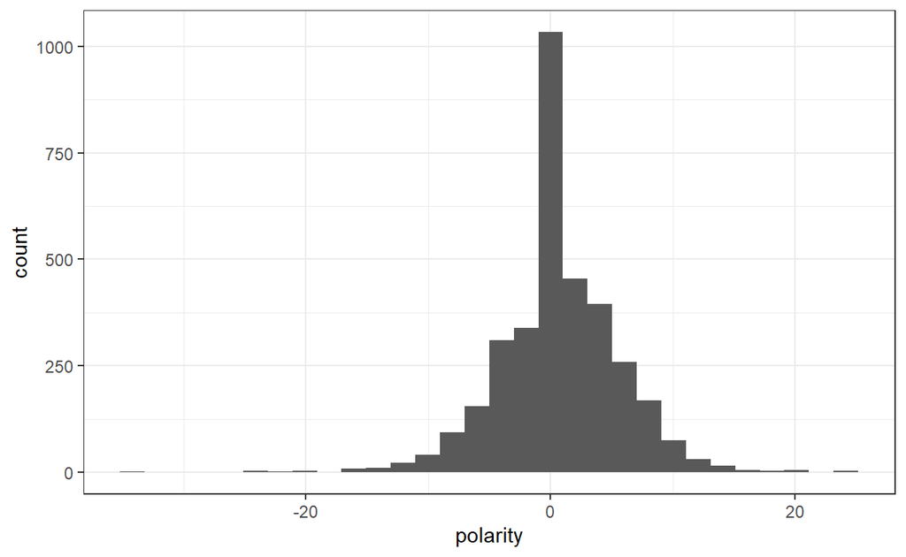

```
Corpus consisting of 38 documents and 11 docvars.
text280 :
"— Parisa, an inmate at Herat Women’s Prison"

text290 :
"This war is different."

text310 :
"[Read the Afghan War Casualty Report from previous months.]"

text432 :
"This is not a time to die."

text455 :
"What happens when the pandemic comes to a country in conflic..."

text479 :
"Donations flooded in to fight the virus devastating the city..."

[ reached max_ndoc ... 32 more documents ]
```

On initial review, I am unsure that I will be able to really capture the sentiment of the articles given that I only have access to the lead paragraph of each article.

It’s possible that another valid approach to analyzing the coverage that may be more viable. There is a clear difference in the way print and online article titles are framed. Perhaps analyzing the sentiment of the titles and comparing them will be the way to go. I will look at that option in my next post.